# Reproducible Research Project 1

## Activity Data Writeup

In this project we have data from 1 activity monitoring device from one anonymous person. We will be looking at their steps taken per day and month over the months of October and November 2012.

First we will read in our data set and remove NA values. In addition, I am going to reformat the date column into POSIX format.

```r
data <- read.csv("activity.csv")
cleandata <- data[!is.na(data$steps),]
cleandata$date <- as.POSIXct(cleandata$date, format="%Y-%m-%d")
```

A histogram of the total number of steps taken each day.

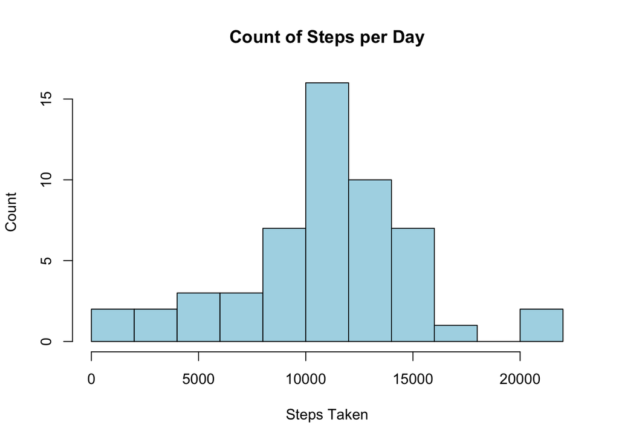

```r
perday <- aggregate(cleandata$steps, by=list(cleandata$date), FUN=sum)
colnames(perday) <- c("date","steps")
hist(c(perday$steps), main = "Count of Steps per Day",
     xlab = "Steps Taken", ylab = "Count",
     breaks = 10, col = "light blue")
```

Next I have determined the mean and median of the number of steps taken per day.

```r
mean(perday$steps, na.rm = TRUE)
```

```
## [1] 10766.19
```

```r
median(perday$steps, na.rm = TRUE)
```

```
## [1] 10765
```

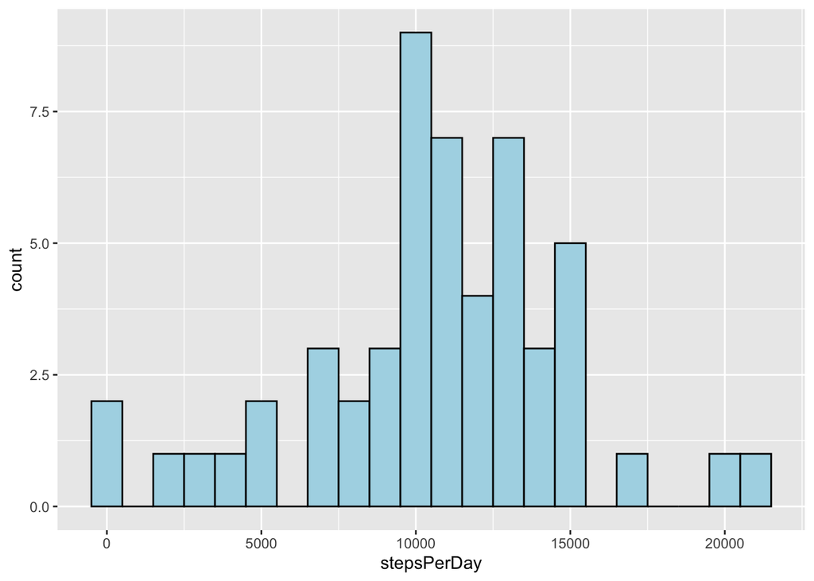

```r
library(ggplot2)
stepsPerDay <- with(data, tapply(steps, date, sum))
ggplot(as.data.frame(stepsPerDay)) +
  geom_histogram(aes(stepsPerDay), fill = "lightblue", col = "black", binwidth = 1000)
```

Now I will find the 5 minute interval that our particpant took the most steps throughout the day.

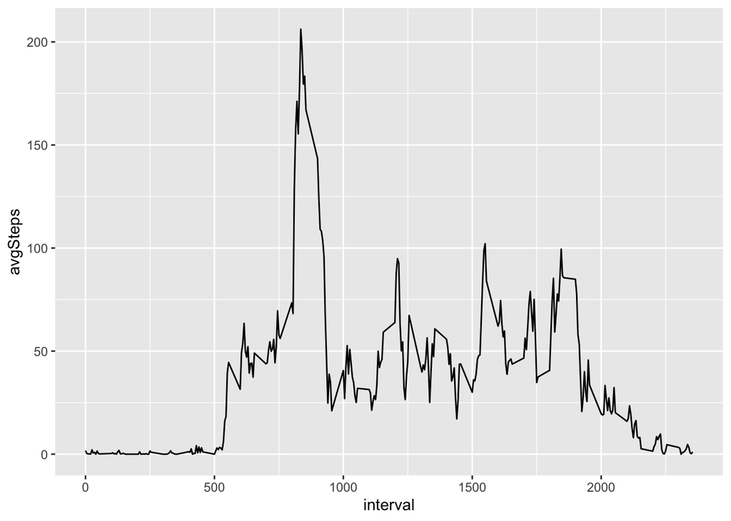

```r
#Calculate the activity pattern by averaging across interval variable.
dailyPattern <- with(data, tapply(steps, interval, mean, na.rm = TRUE))
dailyPattern <- data.frame(interval = as.integer(names(dailyPattern)),
                           avgSteps = unname(dailyPattern))
#plot the pattern.
qplot(interval, avgSteps, data = dailyPattern, geom = "line")
```

```r
#find the interval with the highest number of steps on average.
print(subset(dailyPattern, avgSteps == max(dailyPattern$avgSteps))$interval)
```

```
## [1] 835
```

I will now look for the number of missing values in the raw data set.

```r
nrow(data[is.na(data$steps),])
```

```
## [1] 2304
```

To makeup for the missing values, I am going to replace each missing value, with the mean value for that time period. We will also make a histogram to visualize the difference with the imputted data.

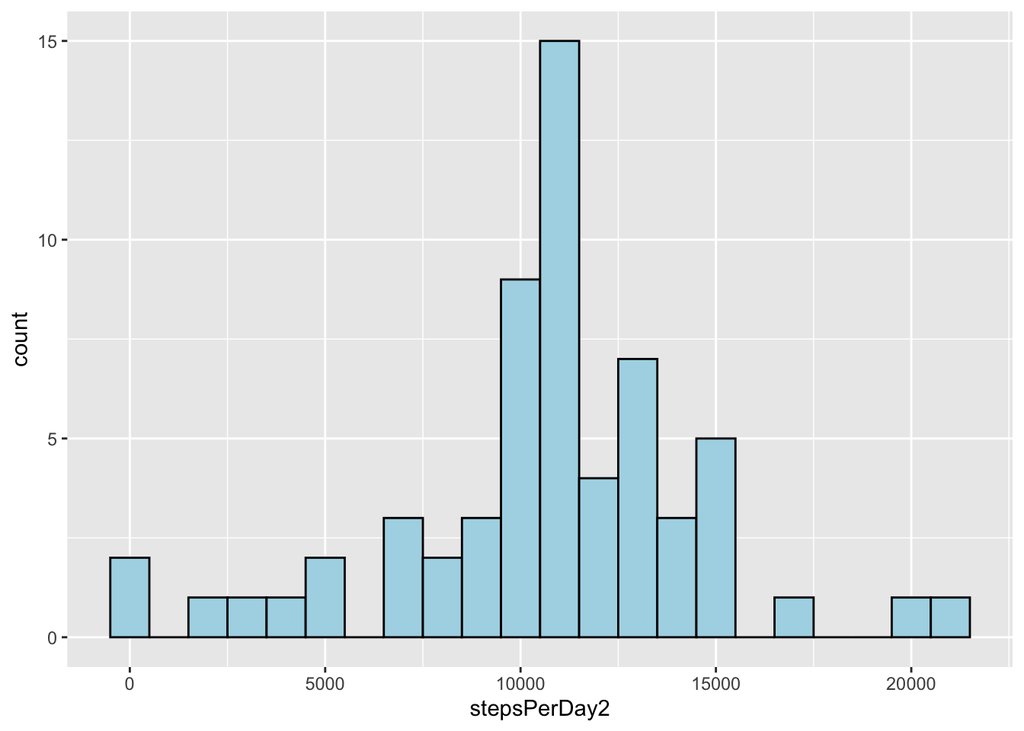

```r
missingData <- data[is.na(data$steps), ]
missingData$steps <-
  dailyPattern$avgSteps[match(missingData$interval, dailyPattern$interval)]
#Create a new dataset that is equal to the original dataset but with the missing data filled in.
#rbind combines the rows, adding the imputed data onto the end of the non-missing original data.
stepDataComplete <- rbind(data[!is.na(data$steps), ], missingData)
#Make a histogram of the total number of steps taken each day and Calculate and report
#the mean and median total number of steps taken per day. Do these values differ from
#the estimates from the first part of the assignment? What is the impact of imputing
#missing data on the estimates of the total daily number of steps?
stepsPerDay2 <- with(stepDataComplete, tapply(steps, date, sum, na.rm = TRUE))
ggplot(as.data.frame(stepsPerDay2)) +
  geom_histogram(aes(stepsPerDay2), fill = "lightblue", col = "black", binwidth = 1000)
```

```r
#Calculate mean and median steps per day.
print(paste("Mean =", round(mean(stepsPerDay2, na.rm = TRUE), 1)))
```

```
## [1] "Mean = 10766.2"
```

```r
print(paste("Median =", round(median(stepsPerDay2, na.rm = TRUE), 1)))
```

```
## [1] "Median = 10766.2"
```

```r
print("The mean has not been altered, because the mean was used when imputing values. The median has been made equal to the mean, because one of the imputed days is now the median value.")
```

```
## [1] "The mean has not been altered, because the mean was used when imputing values. The median has been made equal to the mean, because one of the imputed days is now the median value."
```

Lastly, I am going to check to see if there is any difference in activity levels between weekdays and weekends.

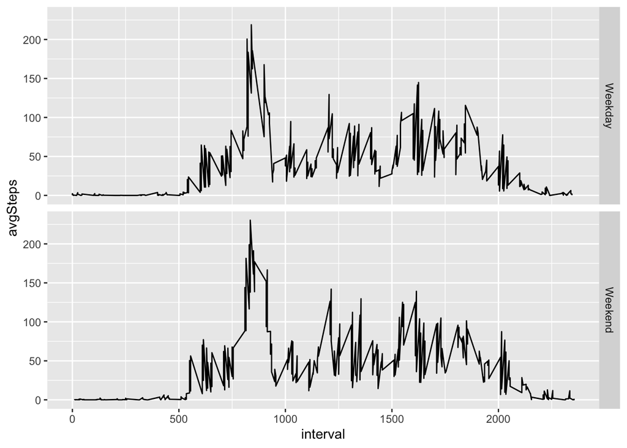

```r
stepDataComplete$date <- as.Date(stepDataComplete$date)
stepDataComplete$weekday <-
  factor(!(weekdays(stepDataComplete$date) %in% c("Saturday", "Sunday")),
         labels = c("Weekday", "Weekend"))
dailyPattern2 <- as.data.frame(with(stepDataComplete, tapply(steps,
                                                        list(interval, weekday),
                                              mean, na.rm = TRUE)))
dailyPattern2 <- data.frame(
  interval = as.numeric(rownames(dailyPattern2)),
  weekday = c(rep("Weekday", length(dailyPattern2)), rep("Weekend",
                                                        length(dailyPattern2))),
  avgSteps = as.numeric(c(dailyPattern2$Weekday, dailyPattern2$Weekend)))
qplot(interval, avgSteps, data = dailyPattern2, geom = "line",
      facets = weekday ~ .)
```